# Time Series Anlaysis. Practice 3. ARIMA Models

# **Exercise 7**

**Consider the ARMA model suggested and estimated by auto.arima for the time series IPC.tr.d1.d12.** **Use the function forecast from library forecast to predict the next 15 values of IPC.tr.d1.d12 (these are the forecasting of the values corresponding to the period from January 2017 to March 2018).** **Plot the forecasted object using plot and autoplot.**

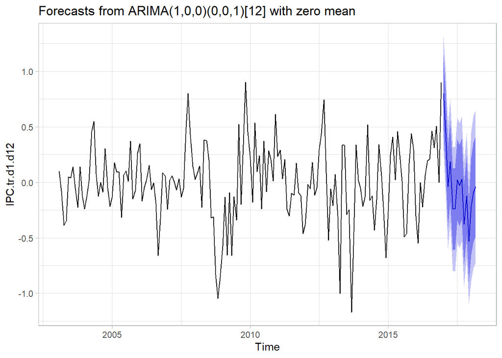

```r
pronos = forecast(auto.arma.IPC.tr.d1.d12,h=15,level=c(80,95))
#Autoplot
autoplot(pronos) +  theme_light()
```

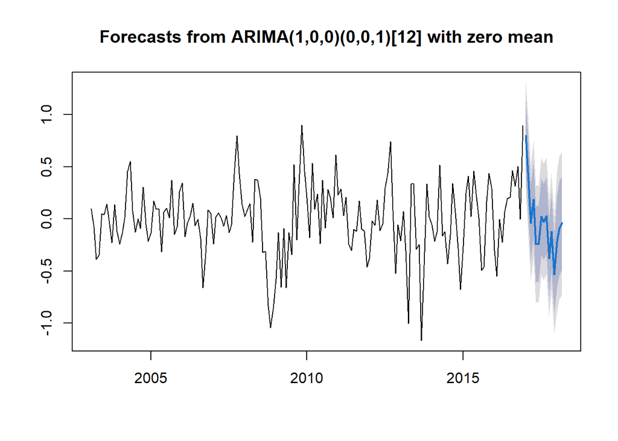

```r
#Plot
plot(pronos)
```

# **Exercise 8**

**Consider the ARIMA model suggested and estimated by auto.arima for the time series IPC.tr. Use the function forecast from library forecast to predict the next 15 values of IPC.tr (these are the forecasting of the values corresponding to the period from January 2017 to March 2018).**

**a. Plot the forecasted object using plot and autoplot.**

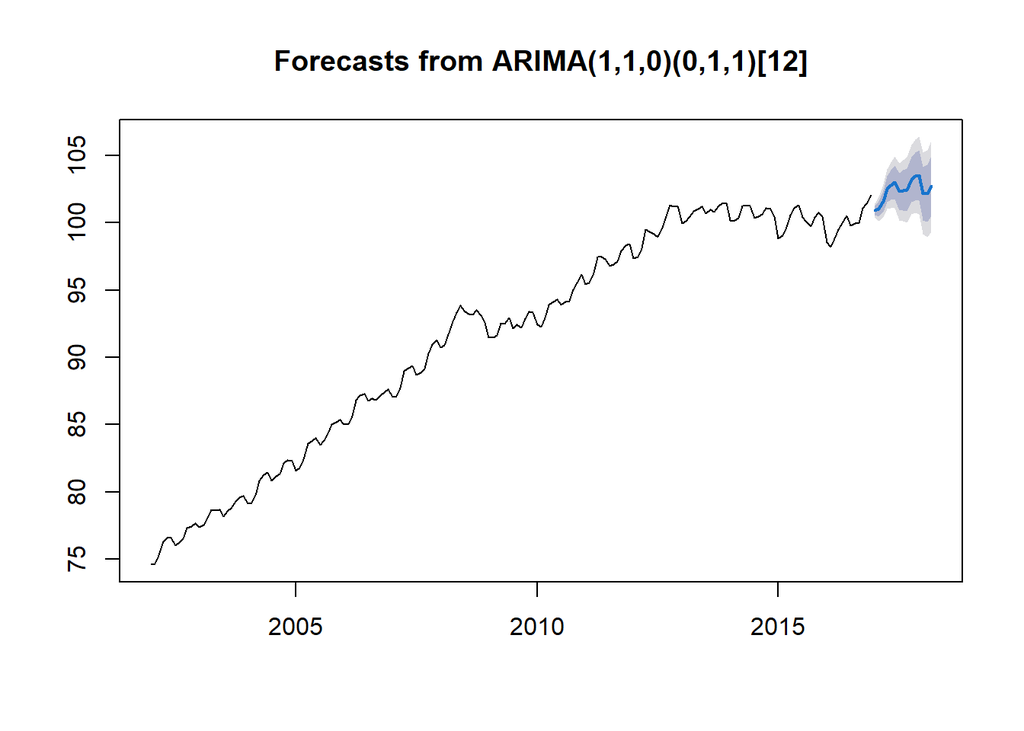

```r
#A
best.arima.IPC.tr = auto.arima(IPC.tr)

plot(forecast(best.arima.IPC.tr, h=15))
```

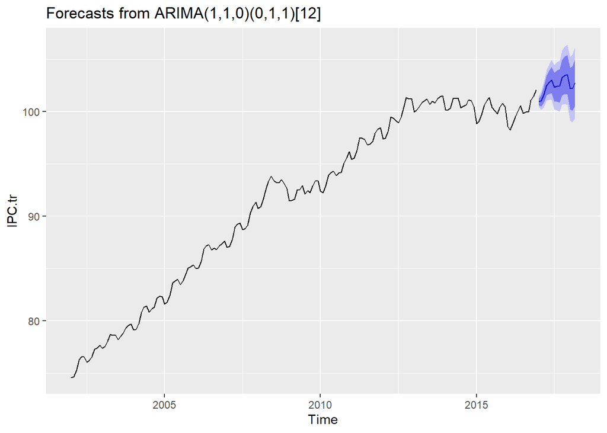

```r
autoplot(forecast(best.arima.IPC.tr, h=15))
```

**b. Compare these predictions with the values of of the test values in IPC.te.**

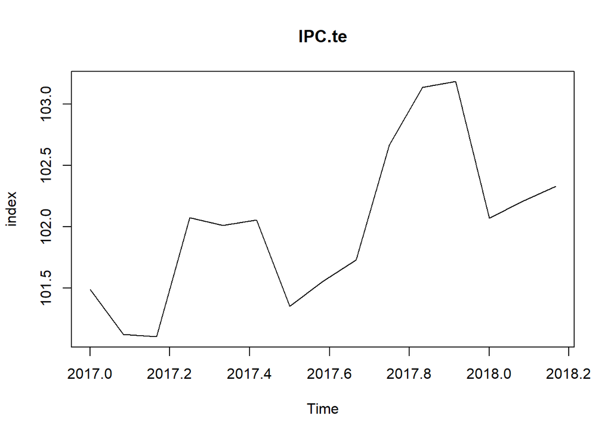

```r
#B
#IPC.TE
plot(IPC.te, main = "IPC.te")
```

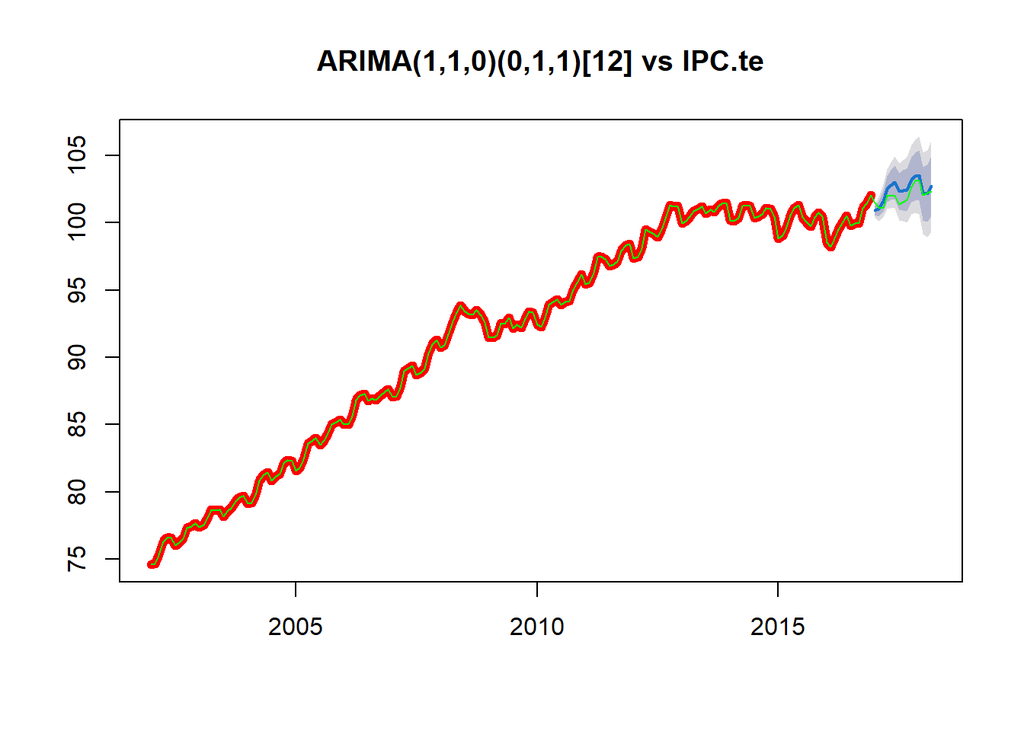

```r
#Comparison
plot(forecast(best.arima.IPC.tr, h=15),col="red", lw=6, main = "ARIMA(1,1,0)(0,1,1)[12] vs IPC.te")
lines(ipcIndex.ts,col="green", lw=1)
```

Se observa que el modelo ARIMA realizo una predicción acertada en cuanto a la tendencia del gráfico y aproximó los valores a los eventos reales de IPC.te.

En el gráfico comparativo podemos observar que los valores de IPC.te están dentro de las bandas de confianza del 80% del modelo ARIMA, por lo cual podemos concluir que, al ser una predicción a corto plazo, es bastante precisa y aproximada a los eventos reales.

# **Exercise 9**

**Compare the predictions obtained by Holt-Winters (last homework) and by the ARIMA model with the true values of IPC (IPC.te).**

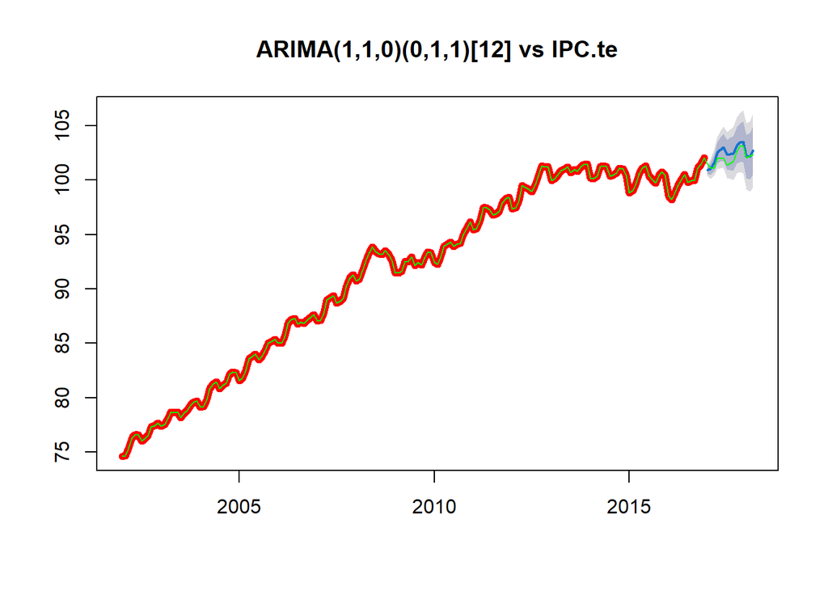

```r
#Comparison ARIMA vs IPC.te
plot(forecast(best.arima.IPC.tr, h=15),col="red", lw=6, main = "ARIMA(1,1,0)(0,1,1)[12] vs IPC.te")
lines(ipcIndex.ts,col="green", lw=1)
```

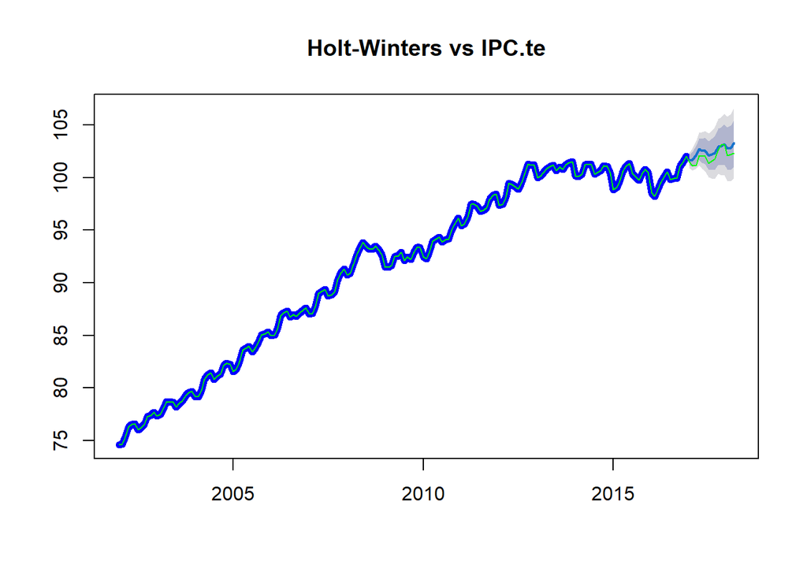

```r
#Comparison Holt-Winters vs IPC.te
IPC.tr.HW = HoltWinters(IPC.tr)
plot(forecast(IPC.tr.HW, h=15),col="blue", lw=6, main = "Holt-Winters vs IPC.te")
lines(ipcIndex.ts,col="green", lw=1)
```

Tanto ARIMA como Holt-winters realizan predicciones bastante parecidas y precisas acorde a los valores reales observados en IPC.te.

Sin embargo, en HW se puede observar un punto del IPC.te alrededor del mes 2 y 3 que se encuentra dentro de la banda de confianza del 95% cuando en ARIMA, todas las observaciones de IPC.te se encuentran dentro del 80%.

Por otra parte, la predicción de HW suaviza la curva más que el modelo ARIMA, y éste último modelo realizó una predicción con mayor precisión de la tendencia y los picos de la curva al seguir el mismo patron que los valores de IPC.te.